# S2 - Crecimiento económico de los E-sports en los Estados Unidos

## Grupo N°2

### Integrantes:

- Dominguez Aspilcueta, Pedro Francisco
- Del Olmo Dulong, Juan Ignacio **(Líder)**
- Chamorro Torres, Jean Pierre
- Munguia Cruzatt, Mauro Sthepano
- Ramos Torres, Guido Antonio

# 1. Introducción

El tema que trata nuestra investigación es sobre la variación económica de los equipos y jugadores de E-sports en los Estados unidos entre los años 2019 y 2020. Para realizar un estudio más completo también se consideran los torneos internacionales en los que participaron jugadores y equipos estadounidenses.

## 1.1 Importancia

La investigación es de importancia para los equipos de E-sport peruanos en proceso de crecimiento, por ejemplo: las casas de juegos o “Gaming Houses’”, torneos locales, torneos entre universidades. Estos torneos son de consumo recurrente en jóvenes adolescentes y muy competitivos. Es así que la alta demanda de equipos muestra tendencias favorables de inversión que podrían ser de valor para pequeños empresarios que están interesados en el mercado E-sport.

Mostrar el crecimiento económico de las E-sports en otros países podría disponer de un mayor panorama para las empresas nacionales interesadas en desarrollar este tipo de torneos en el país.

## 1.2 Objetivos del estudio

Nuestros objetivos se pueden resumir en tres: Hallar relaciones económicas entre juego y grupo de hereditario de jóvenes, por cada torneo ejecutado. Proporcionar información sobre el comportamiento y tiempo de ejecución de cada juego, para hallar un balance entre el tiempo de cada juego contra el monto ganado por torneo. Realizar una predicción para ser de utilidad en la toma de decisiones al momento de invertir un capital en un equipo de E-sports.

## 1.3 Factibilidad

El proyecto es factible debido a tres bases de datos obtenidas de la página de divulgación electrónica, Kaggle. Los datos sobre la cantidad de torneos y los premios monetarios son necesarios para obtener la información específica del dinero generado por cada equipo y jugadores durante los torneos en el periodo 2019-2020.

### 1.3.1 Limpieza de bases de datos

Para los fines de este estudio, en cada dataset se han eliminado resultados cuya información sea corrupta o no necesaria para el estudio. Por ejemplo: Equipos de Esport que no han participado en ningún torneo.

Adicionalmente, se han traducido y renombrado las variables de cada dataset al español para facilitar el estudio.

## 1.4 Hipótesis*

- ¿La categoría del juego influye de manera positiva o negativa en la cantidad de dinero que puede ganar un jugador?
- ¿La categoría del juego influye de manera positiva o negativa en la cantidad de dinero que puede ganar un equipo?
- ¿La nacionalidad del jugador esta relacionado con la cantidad de dinero que genera?
- ¿Han aumentado el número de jugadores a lo largo de los años?
- Si han aumentado el número de torneos, ¿el hecho de que haya aumentado el número de torneos a lo largo de los años ha permitido que aumente el número diferente de jugadores que han generado ingresos?
- ¿Un aumento del número de torneos por año se relaciona con el monto de dinero en premios que los jugadores que participan pueden ganar?

# 2. Presentación de datasets, variables y parámetros de estudio

## 2.1. Datasets

### 2.1.1. Juegos

| Variable | Tipo | Restricciones | Descripción |
| --- | --- | --- | --- |
| Juego | Categórica nominal | Ninguna | El nombre del videojuego |
| Año Lanzamiento | Categórica ordinal | Desde 1980 | El año del lanzamiento del videojuego |
| Premios | Numérica continua | Mayor o igual a 0 | El monto total de premios ofrecidos en todos los torneos del videojuego |
| PremiosOnline | Numérica continua | Mayor o igual a 0 | El monto total de premios ofrecidos en todos los torneos en línea del videojuego |
| Ganadores | Numérica discreta | Mayor o igual a 0 | Número de ganadores en todos los torneos del videjuego |
| Torneos | Numérica discreta | Mayor o igual a 0 | Número total de torneos del videjuego |

###### **Observaciones**

- En la variable ganadores se debe tomar en cuenta que un jugador puede ganar varios torneos.

### 2.1.2. Torneos

| Variable | Tipo | Restricciones | Descripción |
| --- | --- | --- | --- |
| Fecha | Categórica ordinal | Desde 1998 | Año y mes en que se realizó un torneo |
| Juego | Categórica nominal | Ninguna | El nombre del videojuego para el cual se realizaron torneos en esa fecha |
| Premios | Numérica continua | Mayor o igual a 0 | El monto total de premios ofrecidos en esa fecha |
| Ganadores | Numérica discreta | Mayor o igual a 0 | Número de ganadores que hubo en el torneo |
| Torneos | Numérica discreta | Mayor o igual a 0 | Número de torneos en esa fecha |

###### **Observaciones**

- En la variable ganadores se debe tomar en cuenta que un jugador puede ganar varios torneos y por lo tanto puede haber más ganadores que torneos en una unidad muestral.

### 2.1.3. Jugadores

| Variable | Tipo | Restricciones | Descripción |
| --- | --- | --- | --- |
| Usuario | Categórica nominal | Ninguna | Nombre del usuario del jugador |
| Nombres | Categórica nominal | Ninguna | Nombre y apellido del jugador |
| JugadorID | Categórica nominal | Mayor o igual a 0 | Número identificador del jugador |
| IngresosTotales | Numérica continua | Mayor o igual a 0 | Ingresos totales obtenidos en torneos |
| Equipo | Categórica nominal | Ninguna | Nombre del equipo en el que juega |
| IngresosJuego | Numérica continua | Mayor o igual a 0 | Ingresos totales obtenidos en torneos de un juego |
| Juego | Categórica nominal | Ninguna | Nombre del juego |
| Genero | Categórica nominal | Ninguna | Genero del juego |
| Pais | Categórica nominal | Ninguna | País de procedencia |
| CodigoPais | Categórica nominal | Ninguna | Código de país |
| CodigoPaisT | Categórica nominal | Ninguna | Código de país de tres caracteres |
| NroPais | Categórica nominal | Mayor o igual a 0 | Número identificador de país |

### 2.1.4. Equipos

| Variable | Tipo | Restricciones | Descripción |
| --- | --- | --- | --- |
| Equipo | Categórica nominal | Ninguna | Nombre del equipo |
| EquipoID | Categórica nominal | Mayor o igual a 0 | Número identificador del equipo |
| IngresosJuego | Numérica continua | Mayor o igual a 0 | El total de ingresos obtenidos en torneos de un videojuego |
| TorneosGanados | Numérica discreta | Mayor o igual a 0 | Numero de torneos ganados en un juego |
| Juego | Categórica nominal | Ninguna | Nombre del juego de los torneos en el que se participa |
| GeneroJuego | Categórica nominal | Ninguna | Género del juego |
| IngresosTotales | Numérica continua | Mayor o igual a 0 | Ingresos totales obtenidos por el equipo |

### 2.1.5. Equipos-Pais

| Variable | Tipo | Restricciones | Descripción |
| --- | --- | --- | --- |
| Pais | Categórica nominal | Ninguna | Nombre del país |
| IngresosPais | Numérica continua | Mayor o igual a 0 | Ingresos obtenidos en torneos en un país |
| Porcentaje | Numérica continua | Mayor o igual a 0 | El porcentaje de todos los ingresos obtenidos por un equipo |
| Equipo | Numérica discreta | Mayor o igual a 0 | Nombre del equipo |

### 2.1.6. Equipos-Juego

| Variable | Tipo | Restricciones | Descripción |
| --- | --- | --- | --- |
| Juego | Categórica nominal | Ninguna | Nombre del juego |
| IngresosJuegos | Numérica continua | Mayor o igual a 0 | Ingresos obtenidos en torneos de un juego |
| Porcentaje | Numérica continua | Mayor o igual a 0 | El porcentaje de todos los ingresos obtenidos por un equipo |
| Equipo | Numérica discreta | Mayor o igual a 0 | Nombre del equipo |

## 2.2 Descriptores numéricos

```r
summary(Games)
```

```
##     Juego           AñoLanzamiento    Premios          PremiosOnline
##  Length:539         Min.   :1981   Min.   :      118   Min.   :      130
##  Class :character   1st Qu.:2006   1st Qu.:     6003   1st Qu.:    10125
##  Mode  :character   Median :2013   Median :    52723   Median :    60875
##                     Mean   :2011   Mean   :  2139059   Mean   :  1977062
##                     3rd Qu.:2017   3rd Qu.:   297072   3rd Qu.:   352793
##                     Max.   :2021   Max.   :235045551   Max.   :214928871
##                                    NA's   :67          NA's   :156
##    Ganadores          Torneos
##  Min.   :    0.0   Min.   :   1.00
##  1st Qu.:    5.0   1st Qu.:   2.00
##  Median :   21.0   Median :   6.00
##  Mean   :  196.2   Mean   :  90.44
##  3rd Qu.:   94.0   3rd Qu.:  30.00
##  Max.   :14080.0   Max.   :6189.00
##                    NA's   :35
```

```r
Premios = mean(Games$Premios)

round(Premios,2)
```

```
## [1] NA
```

```r
PremiosOnline = round(mean(Games$PremiosOnline, na.rm=TRUE), 2)
```

Media de jugadores que han ganado al menos un torneo por juego

```r
mediaGanadores = mean(Games$Ganadores, na.rm = TRUE)

round(mediaGanadores,0)
```

```
## [1] 196
```

Media de jugadores que han ganado un torneo por mes

```r
mediaJugadores = floor(mean(Tournaments$Ganadores, na.rm = TRUE))
mediaJugadores
```

```
## [1] 52
```

Juego con más torneos organizados en un rango mayor de tiempo.

```r
getmode <- function(v) {
   uniqv <- unique(v)
   uniqv[which.max(tabulate(match(v, uniqv)))]
}
modaJuego = getmode(Tournaments$Juego)
modaJuego
```

```
## [1] "StarCraft: Brood War"
```

La moda es de interés porque indica el juego con mayor tiempo realizando torneos.

### 2.3 Descriptores gráficos

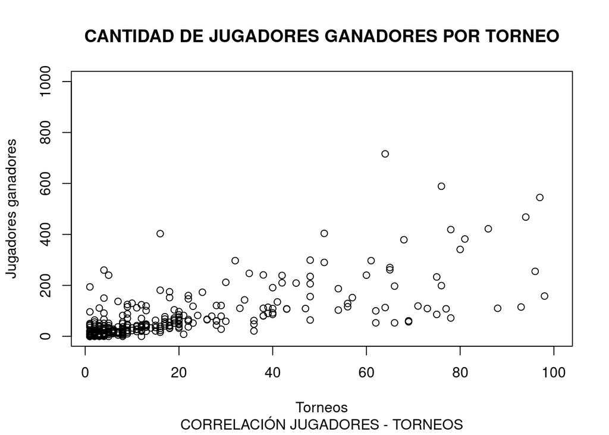

```r
plot(Games$Torneos, Games$Ganadores, main = "CANTIDAD DE JUGADORES GANADORES POR TORNEO", sub = "CORRELACIÓN JUGADORES - TORNEOS", xlab = "Torneos", ylab = "Jugadores ganadores", xlim = c(1,100), ylim = c(1, 1000))
```

En esta gráfica se busca encontrar una relación entre la fecha de lanzamiento de un juego y el monto total de premios ofrecidos en sus torneos. Tal relación parece no existir, sin embargo, se observa que los juegos que ofrecen premios en sus torneos en su mayoría son de la última decada.

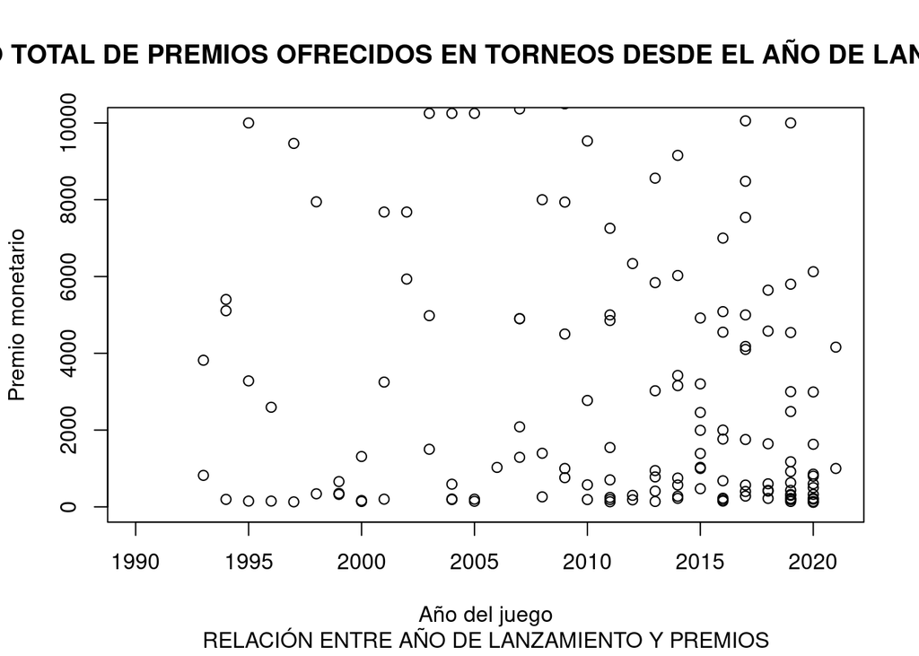

```r
plot(Games$AñoLanzamiento, Games$Premios, main = "MONTO TOTAL DE PREMIOS OFRECIDOS EN TORNEOS DESDE EL AÑO DE LANZAMIENTO", sub = "RELACIÓN ENTRE AÑO DE LANZAMIENTO Y PREMIOS" , xlab = "Año del juego", ylab = "Premio monetario", xlim = c(1990, 2021), ylim = c(1, 10000))
```

En esta gráfica se observa la cantidad de equipos que han ganado al menos un torneo por cada juego. Se observa múltiples equipos que han participado en 5 diferentes juegos y se infiere que es raro que un equipo se dedique de manera exclusiva a un juego.

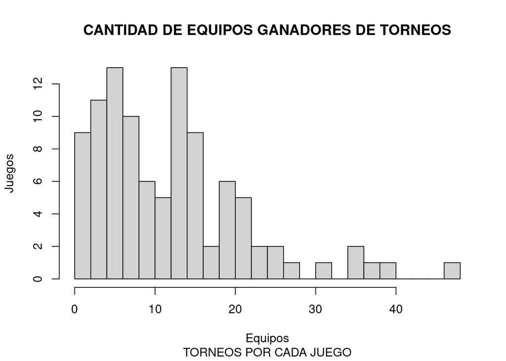

```r
hist(table(Teams_Games$Equipo), breaks = 20, main = "CANTIDAD DE EQUIPOS GANADORES DE TORNEOS", sub = "TORNEOS POR CADA JUEGO", xlab = "Equipos", ylab = "Juegos")
```

[figure not shown]

```r
plot(Teams$TorneosGanados, Teams$IngresosTotales,
     main = "RELACIÓN ENTRE CANTIDAD DE TORNEOS GANADOS Y MONTO TOTAL EN PREMIOS",
     sub = "EQUIPO DE E-SPORTS GANADOR EN UN JUEGO",
     xlab = "Número de torneos ganados",
     ylab = "Monto de los premios",
     xlim = c(1, 100),
     ylim = c(1, 1000000))
```